# Ant community responses to farmland use and revegetation in a fragmented agricultural landscape - ScienceDirect

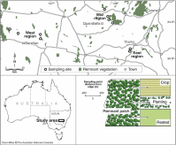

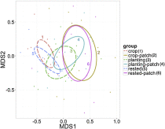

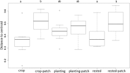

## [Agriculture, Ecosystems & Environment](https://www.sciencedirect.com/science/journal/01678809)

[Volume 311](https://www.sciencedirect.com/science/journal/01678809/311/supp/C), 1 May 2021, 107316

# Ant community responses to farmland use and revegetation in a fragmented agricultural landscape

[KatherinaNg<sup>a</sup>](https://www.sciencedirect.com/science/article/pii/S0167880921000207#!)[SomayehNowrouzi<sup>b</sup>](https://www.sciencedirect.com/science/article/pii/S0167880921000207#!)[Kyran M.Staunton<sup>c</sup><sup>d</sup>](https://www.sciencedirect.com/science/article/pii/S0167880921000207#!)[PhilipBarton<sup>a</sup><sup>e</sup>](https://www.sciencedirect.com/science/article/pii/S0167880921000207#!)[Don A.Driscoll<sup>f</sup>](https://www.sciencedirect.com/science/article/pii/S0167880921000207#!)

https://doi.org/10.1016/j.agee.2021.107316[Get rights and content](https://s100.copyright.com/AppDispatchServlet?publisherName=ELS&contentID=S0167880921000207&orderBeanReset=true)

## Highlights

**•**

Intensive agriculture led to increased homogenisation of the ant community.

**•**

Revegetation plantings appear to reverse those effects within seven years.

**•**

A dominant ant species in remnant patches likely increased community divergence.

**•**

Revegetation near remnant patches can reduce homogenisation of ant communities.

## Abstract

Recent alarming losses of insects from agricultural landscapes in multiple countries around the world have brought into sharp focus the urgent need to identify ways to manage these landscapes to avoid further biodiversity decline. Identifying the drivers of insect declines, such as land use change, is critical to this effort. We examined ant communities at the interface between remnant vegetation patches and three adjoining farmland types (wheat crop, rested from cropping and restoration plantings) in a fragmented landscape in temperate Australia. We asked: do ant communities and occurrence of individual species differ between remnant patches and farmlands with more intensive farmland use (restoration plantings < rested farmlands < wheat crop)? We recorded 13,283 ants belonging to 102 species from 30 genera. Excluding 21 singletons, 27 species only occurred in remnant patches compared to ten species found only in farmlands. Ant community composition in wheat crop and rested farmlands significantly differed from their adjacent remnant patches and were more homogeneous. In contrast, ant communities from restoration plantings in farmland were not significantly different in composition from those in the adjacent remnant patch. The large, aggressive Australian meat ant (*Iridomyrmex purpureus*) showed significantly higher occurrence in the remnant patch than all farmland types, and we suggest that the absence of this strongly interacting species from farmlands may have contributed to biotic homogenisation. Our findings show that native vegetation provides crucial habitat resources for many ant species that are not provided by farmlands, and native plantings can, in some cases, ameliorate negative effects of farmland clearing over relatively short time scales (<7 years). Agricultural intensification that involves loss of remnant native vegetation or reduced revegetation will contribute to ongoing losses and changes to ant biodiversity in farming landscapes. However, replanting native vegetation can lead to rapid restoration, signifying a possible simple remedy to insect declines.

## Keywords

Ant diversity

Biodiversity conservation

Fallow

Matrix

Monitoring

## 1. Introduction

Given the alarming global statistics about the loss of insects from some agricultural landscapes around the world (Cardoso et al., 2020; Hallmann et al., 2017; Lister and Garcia, 2018; Sánchez-Bayo and Wyckhuys, 2019), it is now important to evaluate insect diversity in a range of countries to better understand the extent of the losses. While this accounting is vital, moving beyond counting the declines to understanding the mechanisms leading to the losses is also required. If particular landscape features promote insect diversity and help them remain functional in agricultural landscapes, it could provide a management solution to prevent or reduce declines (Dalle Laste et al., 2019; Harvey et al., 2020; Samways et al., 2020).

Agriculture has led to the erosion of insect diversity at local- and landscape-levels mainly through habitat reduction and fragmentation (Benton et al., 2002; Ollerton et al., 2014; Potts et al., 2010). Conversion of land to agriculture directly reduces the extent of native habitat and is a leading cause of biodiversity loss (Lichtenberg et al., 2017; MacDougall et al., 2013). Further intensification of agricultural areas can have far-reaching indirect impacts on remaining native habitats. Intensification can promote invasion by pasture species (Driscoll et al., 2014), and flourishing of generalist or exotic species in intensively farmed areas can promote biotic homogenisation and associated biodiversity loss (Driscoll et al., 2013; Sweaney et al., 2014). However, there are also many native species, such as generalists and disturbance specialists, that are able to exploit resources in novel habitats (Driscoll et al., 2013). Identifying appropriate management practices within farmlands that minimise edge effects and maintain native communities, for example through revegetation or fallowing, is therefore important for combatting biodiversity loss across agricultural landscapes (Cunningham et al., 2013; Samways et al., 2020).

Ants comprise a major component of biodiversity in many agricultural landscapes in terms of their abundance, species richness, and the ecosystem services they provide such as pest management, soil turnover, pollination, and nutrient cycling (Abensperg-Traun et al., 1996; De Bruyn, 1999; Del Toro et al., 2012; Greenslade and Greenslade, 1984; Lach et al., 2010). Australia has a considerable number of ant species by world standards (over 10,000 species; Andersen, 2016), with many new species yet to be discovered or described (Hoffmann, 2010). The ecology of most species is poorly understood, particularly in modified landscapes where the impacts of agricultural land use changes are largely unknown (Andersen et al., 2004; Barton et al., 2016; Hoffmann and Andersen, 2003). Significant advances in knowledge have been made using ants as bioindicators of landscape disturbance (Andersen and Majer, 2004; De Bruyn, 1999). Yet, many studies are limited to remnant patches of native habitats or specific fields at a local farm scale, and rarely cover multiple land uses at a landscape scale (Abensperg-Traun et al., 1996; De Bruyn, 1999; Majer and Beeston, 1996; Ng et al., 2017). Consequently, we have a poor knowledge of how landscapes might be managed to promote and conserve ant biodiversity.

In this study, we compared ant assemblages from remnant patches of vegetation with assemblages from adjoining farmland types which were either (at the time of sampling) wheat crops, rested from cropping or restoration plantings. Our study was conducted in a highly fragmented mixed-farming landscape in temperate south-eastern Australia. We asked the question: Do ant assemblages and species occurrence differ between remnant patches and adjacent farmlands, and does this difference increase with more intense use of farmland (restoration plantings < rested farmland < cropped farmland)?

We predicted that more structurally and floristically complex habitats with lower intensity of use would support higher ant species richness and higher community heterogeneity (i.e. remnant patch > restoration plantings > rested farmland > cropping farmland). Adjoining farmland type might further influence ant responses in the remnant patch in proportion to intensity of farmland use. Our study therefore aims to help improve knowledge of the effects of agricultural intensification on insects, which is a critical step in recognising causes of declines and potential solutions.

## 2. Materials and methods

### 2.1. Study area

The study was conducted in a highly cleared and fragmented, temperate, mixed grazing–cropping landscape in the New South Wales Lachlan River Catchment, south-eastern Australia. Widespread clearing for agriculture has restricted native *Eucalyptus* woodland patches to infertile steeper areas. Many remnant patches have also been modified by livestock grazing, weed invasion, and altered fire regimes (Norris and Thomas, 1991). Our study comprised ten sites that were clustered across three regions; east (2 sites), mid (4 sites) and west (4 sites). The locations ranged from -34.036 S, 146.363 E; -33.826 S, 147.855 E; to -34.411 S, 148.499 E (Fig. 1).

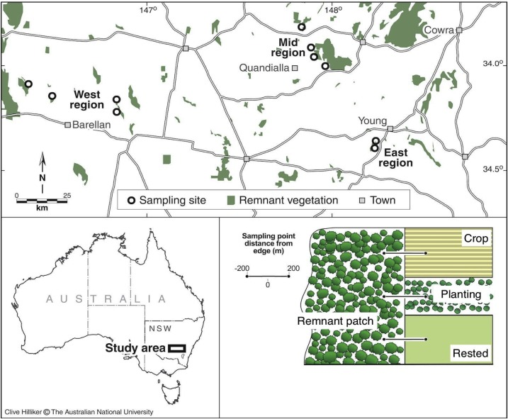

Fig. 1. Location of ten study sites in three regions and experimental design showing placement of pitfall traps at 200 m in a farmland habitat type (crop-farmland, rested-farmland and planting-farmland) and 200 m in a remnant patch habitat adjoining the farmland (crop-patch, rested-patch and planting-patch).

### 2.2. Sampling

We used a split-plot sampling design, with each of the ten sites containing a remnant Eucalyptus woodland patch with areas (crop-patch, rested-patch, planting-patch) that adjoined three farmland types respectively: wheat crop (crop-farmland), rested crop paddock in fallow, grazed by sheep or cattle (rested-farmland), and restoration plantings <7 years old and fenced from livestock (planting-farmland). The ten remnant patches [patch size 4010 ha +/- 486.4 ha (mean +/- SE)] were selected on the basis that they were Eucalyptus woodland communities with high ground-, mid- and over-storey native vegetation complexity (see Fig. 1; details on habitat and vegetation condition in Ng et al., 2018b). In each site, we sampled ants using pitfall stations placed 200 m in the remnant patch and 200 m in the farmland (measured along a 400 m transect across the remnant patch–farmland interface) over 14 days between October and November 2014. A pitfall station comprised two clear, uncovered plastic pitfall traps (6.5 cm diameter, 250 ml) placed on either side of a drift fence (60 cm long x10 cm high). Traps were buried in the ground with the rim level with the soil surface, and filled with 100 ml of 1:3 glycol–water mixture. The traps were collected at the end of the 14 days of trapping period and inspected at the end of the first week.

Ant samples were preserved in 70 % ethanol. All ants were sorted to morpho-species following Shattuck (2000), and where possible named through comparison with identified specimens held in the CSIRO Tropical Ecosystems Research Centre ant collection, referring to the latest ant nomenclature. A full set of voucher specimens were deposited in the CSIRO Ant Lab collection.

### 2.3. Analyses

We pooled ant samples from the two pitfall traps in each of the 60 stations to give one sample per station for statistical analyses. We converted count data to absence-presence for species-level analyses. Presence-absence is recommended over abundance when studying pitfall-trapped ant species data because abundances for some species can be spuriously inflated for traps that are located near ant nests (Yeeles et al., 2017).

We examined the composition of ant assemblages using four multivariate approaches. First, we used non-metric multidimensional scaling (nMDS) to visualise overall differences in ant species composition (presence/absence data, singletons omitted) between the remnant patch and adjoining farmland types (crop, rested and planting), using the *vegan* R package's *metaMDS* function (Oksanen et al., 2013) and Sørensen dissimilarities among samples (Clarke, 1993).

Second, we tested for differences in ant composition among the three farmland types *and* among the remnant patch, separating patches by their adjacent farmland type, giving six groups: crop-farmland, rested-farmland, plantings-farmland, remnant patch beside crop (crop-patch), remnant patch beside rested (rested-patch), remnant patch beside planting (planting-patch). To do this we used permutational multivariate analysis of variance (PERMANOVA), based on Sørensen dissimilarities and 999 permutations, and with P-values adjusted using sequential Bonferroni corrections to account for multiple comparisons. We used the *pairwise.adonis* function based on the vegan package (Martinez Arbizu, 2019), and the *multcompView* package's *multcompLetters* function to present pairwise comparisons as letters (Graves et al., 2015).

Significant results in PERMANOVA might be due to dissimilarity differences between the six above-mentioned groups (differences between the group’s centroid location in multivariate space), or differences in the within-category dispersion (mean distance to group centroid), or both. To determine if a significant PERMANOVA result is due to differences between categories (likely turnover) or differences within categories (likely nestedness), we performed an additional permutational analysis of multivariate dispersions (PERMDISP) (Anderson, 2006; Anderson et al., 2006). We ran PERMDISP with 999 permutations, among the six above-mentioned groups (transect-habitat pairs) and tested for pairwise differences using functions *betadisper* and *permutest* in the *vegan* package (Oksanen et al., 2013). We interpreted our findings as follows: a significant result for PERMANOVA *but not* PERMDISP indicates there are differences due to species turnover, but a significant result for PERMANOVA *and* PERMDISP indicates there may be differences due to both species turnover and nestedness (Anderson et al., 2011). We used Tukey’s HSD test based on Bray–Curtis dissimilarities to identify pair-wise differences in ant communities between the six groups (transect-habitat pairs) where the PERMDISP results were significant.

To determine which species’ occurrence significantly contributed to any compositional differences between the six groups of transect-habitat pairs, we conducted Dufrene-Legendre indicator species analysis over the absence-presence data (Dufrêne and Legendre, 1997) to identify ant species fidelity to the different habitat types in two ways: (1) comparing between the remnant patch and all farmland types combined, and (2) comparing between the six groups of transect-habitat pairs. We tested for IndVal significance using a random reallocation procedure with 1000 permutations using the *indval* function in the *labdsv* package, and IndVal values > 0.3 and P < 0.05 were inferred as strong indicators (Roberts, 2010).

Finally, we examined species richness of ant community as well as the occurrence (presence/absence) of abundant ant species using generalized linear mixed-effect models (GLMMs), with the glmer function in the *lme4* package (Bates et al., 2015). The purpose of our latter analysis was to identify the effects of 'habitat', effects of 'transect', or interactive effects of 'transect' and 'habitat'. We fitted 'site' and 'farmland-patch pair' associated with the transect as nested random effects (1|site/'farmland-patch pair') to account for the non-independent spatial structure of the study design. To control for possible effects of region (three levels: east, mid, west), we included that as an additive fixed effect. We used a Poisson distribution with log link function for species richness count data, and a binomial distribution with a *logit link* function for presence-absence response variables of individual species. We then checked model fit by examining residual and fitted plots, and checked for overdispersion by dividing the Pearson goodness-of-fit statistic by the residual degrees of freedom and ensuring values were below one (McCullagh and Nelder, 1989). Where there was evidence of overdispersion, we fitted individual-level random effects (Maindonald and Braun, 2006). We used Wald tests (*Anova* function in the *car* package (Fox et al., 2013)) to identify the statistical significance of fixed effects and pairwise post hoc Tukey-Kramer tests (*glht* function in the *multcomp* package (Hothorn et al., 2008)) to evaluate between-treatment response differences.

## 3. Results

We sampled 13,283 ants, consisting of 102 species across 30 genera (21 singleton species) (Appendix S1). The most abundant genera sampled were: *Iridomyrmex* (n = 8,218, 11 species), *Pheidole* (n = 1,845, 9 species), *Monomorium* (n = 1,064, 12 species) and *Rhytidoponera* (n = 1,029, 4 species). The species with the greatest abundance included *Iridomyrmex* nr. *chasei* (n = 7026), *Pheidole* sp. P2. *pyriformis* gp. (n = 1028), *Rhytidoponera metallica* (n = 986), *Monomorium* sp. S1 *sordidum* gp. (n = 895), *Iridomyrmex purpureus* (n = 809).

Of the 102 species we collected, we found that 27 species only occurred in remnant patches (when excluding singletons at each site), 10 species only occurred in farmland, and 44 species were found across both habitat types. Within the farmland, two species were only recorded in crop farmland *(Monomorium* sp. R1 *rothsteini* gp*., Rhytidoponera* nr*. victoriae)*, two species only occurred in rested farmland *(Doleromyrma* sp. A*, Tetramorium* sp. IB *impressum* gp.), and three species only occurred in plantings (*Hypoponera* sp. B, *Pheidole* sp. V2 *variabilis* gp., *Iridomyrmex* nr*. splendens)* (Appendix S1).

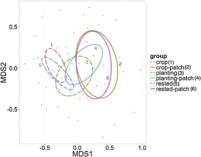

Fig. 2. NMDS of ant community composition by the six transect-habitat groups. Circles show standard deviation ellipses to visualise community dispersion.

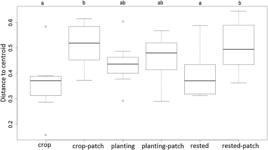

Fig. 3. Box-plots showing within-habitat variability (multivariate dispersion) of the ant community for the three farmland types (crop-farmland, rested-farmland, planting-farmland) and remnant patches adjoining these (crop-patch, rested-patch, planting-patch). Different letters above the figure indicate significant differences between categories. Boxes indicate upper and lower quartiles, whiskers indicate 1.5 x interquartile range, and points indicate outliers.

PERMANOVA tests confirmed significant compositional differences between the rested farmland and its adjoining remnant patch (rested-patch) (adjusted *P* = 0.015), and between the crop farmland and its adjoining remnant patch (crop-patch) (adjusted *P* = 0.015). Ant community composition was not significantly different between the planting farmland and its adjoining remnant patch (planting-patch) (adjusted *P* = 1.000; Table 1).

Table 1. Pairwise comparisons of ant species composition dissimilarity based on PERMANOVA, and ant community variability based on PERMDISP, between six groups of different transect-habitat pairs: crop-patch, crop-farmland, rested-patch, rested-farmland, planting-patch, planting-farmland. PERMANOVA significance levels adjusted by Bonferroni correction. Significant values (P < 0.05) shown with asterisk (*). Tukey’s HSD test for PERMDISP: ‘diff’ = difference between treatments, with positive value indicating higher among-sample variability in the first treatment of the pairwise comparison. (^ indicate pairwise comparisons of interest in this study).

| Pairwise comparisons | PERMANOVA Permutation P | PERMDISP Observed P | Tukey’s HSD in variability Diff | Tukey’s HSD in variability P adjusted |
| --- | --- | --- | --- | --- |
| crop-patch vs. crop-farmland^ | 0.015* | 0.004* | 0.156 | 0.005* |
| planting-farmland vs. crop-farmland | 0.540 | 0.059 | 0.081 | 0.375 |
| planting-patch vs. crop-farmland | 0.255 | 0.034 | 0.102 | 0.151 |
| rested-farmland vs. crop-farmland | 1.000 | 0.433 | 0.038 | 0.946 |
| rested-patch vs. crop-farmland | 0.015* | 0.007* | 0.142 | 0.014* |
| planting-farmland vs. crop-patch | 0.495 | 0.068 | −0.074 | 0.470 |
| planting-patch vs. crop-patch | 1.000 | 0.181 | −0.054 | 0.783 |
| rested-farmland vs. crop-patch | 0.120 | 0.019* | −0.118 | 0.077 |
| rested-patch vs. crop-patch | 1.000 | 0.729 | −0.014 | 0.999 |
| planting-patch vs. planting-farmland^ | 1.000 | 0.607 | 0.021 | 0.996 |
| rested-farmland vs. planting-farmland | 1.000 | 0.308 | −0.043 | 0.910 |
| rested-patch vs. planting-farmland | 1.000 | 0.279 | 0.061 | 0.683 |
| rested-farmland vs. planting-patch | 1.000 | 0.143 | −0.064 | 0.660 |
| rested-patch vs. planting-patch | 1.000 | 0.328 | 0.040 | 0.926 |
| rested-patch vs. rested-farmland^ | 0.015* | 0.029* | 0.104 | 0.158 |

*Iridomyrmex purpureus* was a significant indicator species in terms of their presence in the remnant patch compared to farmlands (all types). *Pheidole* sp. P2 *pyriformis* gp. and *Nylanderia* sp. A were significant indicator species in farmlands compared to the remnant patch (Appendix S2).

GLMM analyses showed that overall ant species richness did not vary significantly among habitat (remnant patch vs. farmland) or among the different farmland types (*P* > 0.140) (Table S1a). When assessing the occurrence of individual species using GLMM, only *I. purpureus* showed significant habitat effects (*P* = 0.014); it occurred in approximately half of the remnant patches compared with only 10 % of the farmland sites (Appendix S3; Appendix S4).

## 4. Discussion

We found lower variability (lower dispersion) in ant community composition, as well as relatively lower number of unique species, in crop and rested farmlands compared to remnant patches. These findings can be explained by reduced habitat structure, food resources and microclimatic range in cultivated farmlands (Andersen, 1995; Ekroos et al., 2010; Ng et al., 2018a, b; Pereyra et al., 2019; Yates et al., 2012), and the biotic influence of a dominant ant species in remnant patches (Greenslade, 1976). Removal and modification of native vegetation are the primary drivers of the loss of many insect species (Cardoso et al., 2020; Hobbs et al., 2018). Finding a combination of significant differences in community dispersion within groups (transect-habitat pairs), as well as spatial turnover and convergence in community composition, suggests homogenisation of ant assemblages in cultivated farmlands with more generalist species such as strong dispersers and disturbance-tolerant species becoming more common (McKinney and Lockwood, 1999). Long-term studies indicate limited adaptability of many insect species to intensified agricultural practices characterised by monocropping, high soil disturbance (Abensperg-Traun et al., 1996; Lövei and Sunderland, 1996; Stinner and House, 1990) and agrochemical use (Cunningham et al., 2013; Goulson et al., 2015; Sutcliffe et al., 2015; Tscharntke et al., 2005). These intensive agricultural practices are typical of broad acre cropping in southern Australia.

Our remnant patches are associated with strong environmental spatial heterogeneity that can shape insect community structure at a patch level (Gibb, 2012), particularly through variations in localised disturbance (e.g. grazing pressure), vegetation structure, soil type (Barton et al., 2016; Hoffmann, 2000), and microclimatic conditions (Barton et al., 2016; Gibb, 2012). The spatial arrangement and amount of habitat can also have a strong influence on habitat-specialist insects (Driscoll, 2008; Driscoll et al., 2010) and in some cases, random compositional drift is also possible. The combination of these forces likely contribute to heterogeneity of ant communities in these less disturbed sites. These contrast with the frequently disturbed crop and rested paddocks that generate more homogenous communities. Protection of remnant vegetation and appropriate farm management practices are needed to minimise losses in insect biodiversity and the important ecological functions they provide (De Bruyn, 1999; Samways et al., 2020; Yates et al., 2012).

Increased similarity in community composition between restoration plantings and their adjacent remnant patches provides evidence that native plantings are an effective restoration tool for ant communities over relatively short periods (< 7 years). We also found greater community dispersion when farmlands are restored with native plantings, indicating that restoration can increase ant community heterogeneity. This finding is in agreement with studies on the ability of ant communities to rapidly recover following revegetation of farmlands through the provisioning of habitat structure and resources similar to remnant patches (Colloff et al., 2010; Gibb and Cunningham, 2013; Lomov et al., 2009). In our study landscape, recently established plantings are associated with increased habitat complexity from native trees and shrubs (*Eucalyptus*, *Acacia*) and increased ground-layer from the exclusion of livestock (Ng et al., 2018b), which are features that are characteristic of remnant patches. These features provide a combination of plant sugar resources, suitable nesting habitats and microclimatic conditions critical for many ant species (Gibb, 2012). While we demonstrate that revegetation adjacent to remnant vegetation can lead to rapid recovery of ant communities, an important next question to address is whether the same benefits arise from revegetation that is not adjacent to a source of potential colonists. Reintroductions may be necessary in more isolated plantings.

*Iridomyrmex purpureus* was an indicator species for remnant patches in our study, and was five times more likely to occur in the remnant patches than farmlands. Many *Iridomyrmex* species are woodland specialists that are disadvantaged by agricultural disturbance (Abensperg-Traun et al., 1996; Hoffmann, 2000; Majer, 1976) because they depend on nectar and scale insect exudate found on native shrubs and trees (Barton et al., 2016; Davidson et al., 2004). Species of *Iridomyrmex* can also be highly aggressive and dominate other ant species (Andersen, 1993; Greenslade, 1976), and aggressive species in other taxa have a profound influence on community composition (Driscoll and Lindenmayer, 2010). We therefore speculate that the presence of *Iridomyrmex* in remnant vegetation may have an important role in driving the observed community divergence, and conversely, that its loss allowed homogenisation and changes to community structure in the cropped and rested paddocks.

This dominant *Iridomyrmex* ant species appears to provide opportunities for a diverse range of communities to establish across different remnant patches. After vegetation clearing and the environmental exclusion of dominant *Iridomyrmex* however, opportunist species such as *Pheidole* sp. and *Nylanderia* sp. (Barton et al., 2016; Hoffmann and Andersen, 2003) may be able to dominate this new environment, driving homogenisation of the ant community. Similarly, the opportunist species *Monomorium* sp. R1 and *Rhytidoponera* nr. *victoriae* were only found in the crop, where the latter is a cosmopolitan genus characteristic of disturbed areas with low diversity (Andersen, 1997; Hoffmann and Andersen, 2003). The divergence in community composition between crop/rested farmland and adjacent remnant patches may therefore be explained by environmental limits that exclude the dominant *Iridomyrmex* species from farmlands, potentially enabling more generalist species to dominate farmlands. The competitive influence of the observed opportunist species in farmland and their role in determining ant community structure are, however, unclear and need further investigation, as is the precise mechanism by which *Iridomyrmex* presence allows divergent communities to form.

Species richness was unchanged between the different land uses (both the remnant patch and the different farmland types) in our study, with one species (*I. purpureus*) showing higher occurrence in the remnant patch. Multivariate approaches accounting for habitat differences were important in further teasing out changes in ant community composition to land use effects. Two species (*Pheidole* sp. P2 *pyriformis* gp. and *Nylanderia* sp. A), were found to be indicators of farmlands (all types) and contributed significantly to compositional differences between the farmland and remnant patch. Our findings reinforce previous assertions on the low utility of broad measures of species richness in uncovering ant responses to land use changes, with many studies determining species composition to be more consistently sensitive to soil and vegetation changes associated with land management (Andersen and Majer, 2004; Barton et al., 2016; Dalle Laste et al., 2019; Hoffmann, 2010;de Castro Solar et al., 2016).

Overlaps of over 30 % of species at the interface between the farmlands and their adjoining remnant patches show that a proportion of species were able to use both the farmland and remnant patch habitats. The majority of these species are native and it is notable that some native species were able to use farmlands. For example, *Nylanderia* sp. A and *Pheidole* sp. P2 *pyriformis* gp. were found in all habitats, but being opportunist species that prefer open areas (Barton et al., 2016), they showed stronger association with the farmland than the adjacent remnant patch in our study. Farmlands can potentially provide extensive habitat for opportunistic species, ensuring persistence of at least a proportion of native species in these highly modified landscapes (Driscoll and Weir, 2005; Ng et al., 2017).

## 5. Conclusion

We conclude that land use intensification led to homogenisation of the ant community, with loss of species that depend on elements of native vegetation and expansion of generalist and disturbance-preferring species. We found that many ant species were dependent on native woodland vegetation, with mixed cropping-grazing farmlands exhibiting lower variability in ant community composition than remnant patches. We further suggest the association between native vegetation losses and the loss of biotic influence of dominant *Iridomyrmex* species as a possible driver of homogenisation of ant community assemblage.

Our findings underscore the importance of retaining native vegetation as current intensive mixed cropping-grazing practices appear to be unsympathetic to many ant species and risks biotic homogenisation. Besides retaining remnant patches within a heterogeneous mix of modified land use types, planting native trees and shrubs in farmlands can have positive impacts on ant communities over relatively short time scales, and is a simple remedy to potential insect declines. This discovery provides substantial encouragement for investing in habitat restoration, especially where this can be undertaken adjacent to remnant native vegetation.

## Declaration of Competing Interest

The authors declare that they have no known competing financial interests or personal relationships that could have appeared to influence the work reported in this paper.

## Acknowledgements

This work was supported by Central Tablelands Local Land Services, Lake Cowal Foundation and Australian Government Research Training Program funding. Thanks to landholders (Day, Foy, Conlan, Hall, Lucas, Nowlan, Aylott, Grimm, Robinson, Crawford, Daley families) for property access. We are grateful to many volunteers for assistance in the field and lab, and to Alan Andersen for providing ant identification expertise.

## Appendix A. Supplementary data

The following is Supplementary data to this article:[Download : Download Word document (267KB)](https://ars.els-cdn.com/content/image/1-s2.0-S0167880921000207-mmc1.docx)

## References

**Abensperg-Traun et al., 1996**

M. Abensperg-Traun, G.T. Smith, G.W. Arnold, D.E. Steven

**The effects of habitat fragmentation and livestock-grazing on animal communities in remnants of Gimlet *Eucalyptus salubris* woodland in the Western Australian wheatbelt. I. Arthropods**

J. Appl. Ecol., 33 (1996), pp. 1281-1301, 10.2307/2404771

[CrossRef](https://doi.org/10.2307/2404770)[View Record in Scopus](https://www.scopus.com/inward/record.url?eid=2-s2.0-0030302428&partnerID=10&rel=R3.0.0)Google Scholar

**Andersen, 1993**

A.N. Andersen

**Ant communities in the gulf region of Australia semiarid tropics - species composition, patterns of organization, and biogeography**

Aust. J. Zool., 41 (1993), pp. 399-414, 10.1071/ZO9930399

[View Record in Scopus](https://www.scopus.com/inward/record.url?eid=2-s2.0-0027333039&partnerID=10&rel=R3.0.0)Google Scholar

**Andersen, 1995**

A.N. Andersen

**A classification of Australian ant communities, based on functional groups which parallel plant life-forms in relation to stress and disturbance**

J. Biogeogr. (1995), pp. 15-29, 10.2307/2846070

[CrossRef](https://doi.org/10.2307/2846070)[View Record in Scopus](https://www.scopus.com/inward/record.url?eid=2-s2.0-0028981835&partnerID=10&rel=R3.0.0)Google Scholar

**Andersen, 1997**

A. Andersen

**Functional groups and patterns of organization in North American ant communities: a comparison with Australia**

J. Biogeogr., 24 (1997), pp. 433-460, 10.1111/j.1365-2699.1997.00137.x

[View Record in Scopus](https://www.scopus.com/inward/record.url?eid=2-s2.0-0030662555&partnerID=10&rel=R3.0.0)Google Scholar

**Andersen, 2016**

A.N. Andersen

**Ant megadiversity and its origins in arid Australia**

Aust. Entomol., 55 (2016), pp. 132-137, 10.1111/aen.12203

[CrossRef](https://doi.org/10.1111/aen.12203)[View Record in Scopus](https://www.scopus.com/inward/record.url?eid=2-s2.0-84963525416&partnerID=10&rel=R3.0.0)[Google Scholar](https://scholar.google.com/scholar_lookup?title=Ant%20megadiversity%20and%20its%20origins%20in%20arid%20Australia&publication_year=2016&author=A.N.%20Andersen)

**Andersen and Majer, 2004**

A.N. Andersen, J.D. Majer

**Ants show the way down under: invertebrates as bioindicators in land management**

Front. Ecol. Environ., 2 (2004), pp. 291-298, 10.1890/1540-9295(2004)002[0292:ASTWDU]2.0.CO;2

[View Record in Scopus](https://www.scopus.com/inward/record.url?eid=2-s2.0-28144457782&partnerID=10&rel=R3.0.0)Google Scholar

**Andersen et al., 2004**

A.N. Andersen, A. Fisher, B.D. Hoffmann, J.L. Read, R. Richards

**Use of terrestrial invertebrates for biodiversity monitoring in Australian rangelands, with particular reference to ants**

Austral Ecol., 29 (2004), pp. 87-92, 10.1111/j.1442-9993.2004.01362.x

[View Record in Scopus](https://www.scopus.com/inward/record.url?eid=2-s2.0-1542350724&partnerID=10&rel=R3.0.0)Google Scholar

**Anderson, 2006**

M.J. Anderson

**Distance-based tests for homogeneity of multivariate dispersions**

Biom, 62 (2006), pp. 245-253

https://www.jstor.org/stable/3695727

[CrossRef](https://doi.org/10.1111/j.1541-0420.2005.00440.x)[View Record in Scopus](https://www.scopus.com/inward/record.url?eid=2-s2.0-33645053483&partnerID=10&rel=R3.0.0)[Google Scholar](https://scholar.google.com/scholar_lookup?title=Distance-based%20tests%20for%20homogeneity%20of%20multivariate%20dispersions&publication_year=2006&author=M.J.%20Anderson)

**Anderson et al., 2006**

M.J. Anderson, K.E. Ellingsen, B.H. McArdle

**Multivariate dispersion as a measure of beta diversity**

Ecol. Lett., 9 (2006), pp. 683-693, 10.1111/j.1461-0248.2006.00926.x

[CrossRef](https://doi.org/10.1111/j.1461-0248.2006.00926.x)[View Record in Scopus](https://www.scopus.com/inward/record.url?eid=2-s2.0-33646827806&partnerID=10&rel=R3.0.0)[Google Scholar](https://scholar.google.com/scholar_lookup?title=Multivariate%20dispersion%20as%20a%20measure%20of%20beta%20diversity&publication_year=2006&author=M.J.%20Anderson&author=K.E.%20Ellingsen&author=B.H.%20McArdle)

**Anderson et al., 2011**

M.J. Anderson, T.O. Crist, J.M. Chase, M. Vellend, B.D. Inouye, A.L. Freestone, N.J. Sanders, W.V. Cornell, L.S. Comita, K.F. Davies, S.P. Harrison, N.J.B. Kraft, J.C. Stegen, N.G. Swenson

**Navigating the multiple meanings of β diversity: a roadmap for the practicing ecologist**

Ecol. Lett., 14 (2011), pp. 19-28, 10.1111/j.1461-0248.2010.01552.x

[CrossRef](https://doi.org/10.1111/j.1461-0248.2010.01552.x)[View Record in Scopus](https://www.scopus.com/inward/record.url?eid=2-s2.0-78650061319&partnerID=10&rel=R3.0.0)[Google Scholar](https://scholar.google.com/scholar?q=Navigating%20the%20multiple%20meanings%20of%20%20diversity:%20a%20roadmap%20for%20the%20practicing%20ecologist)

**Barton et al., 2016**

P.S. Barton, C.F. Sato, G.M. Kay, D. Florance, D.B. Lindenmayer

**Effects of environmental variation and livestock grazing on ant community structure in temperate eucalypt woodlands**

Insect Conserv. Divers., 9 (2016), pp. 124-134, 10.1111/icad.12151

[CrossRef](https://doi.org/10.1111/icad.12151)[View Record in Scopus](https://www.scopus.com/inward/record.url?eid=2-s2.0-84959524212&partnerID=10&rel=R3.0.0)Google Scholar

**Bates et al., 2015**

D. Bates, M. Maechler, B. Bolker, S. Walker, R.H.B. Christensen, H. Singmann, B. Dai, G. Grothendieck, P. Green, M.B. Bolker

**lme4: Fitting Linear Mixed-effects Models Using Eigen and S4 (R Package version1.1-8)**

(2015)

https://cran.r-project.org/web/packages/lme4/lme4.pdf

[Google Scholar](https://scholar.google.com/scholar?q=lme4:%20Fitting%20Linear%20Mixed-effects%20Models%20Using%20Eigen%20and%20S4)

**Benton et al., 2002**

T.G. Benton, D.M. Bryant, L. Cole, H.Q. Crick

**Linking agricultural practice to insect and bird populations: a historical study over three decades**

J. Appl. Ecol., 39 (2002), pp. 673-687, 10.1046/j.1365-2664.2002.00745.x

[View Record in Scopus](https://www.scopus.com/inward/record.url?eid=2-s2.0-0036054739&partnerID=10&rel=R3.0.0)Google Scholar

**Cardoso et al., 2020**

P. Cardoso, P.S. Barton, K. Birkhofer, F. Chichorro, C. Deacon, T. Fartmann, C. Fukushima, R. Gaigher, J. Habel, C. Hallmann, M. Hill, A. Hochkirch, M. Kwak, S. Mammola, J. Noriega, A. Orfinger, F. Pedraza, J. Pryke, F. Roque, J. Settele, J. Simaika, N. Stork, F. Suhling, C. Vorster, M. Samways

**Scientists’warning to humanity on insect extinctions**

Biol. Conserv., 242 (2020), Article 108426, 10.1016/j.biocon.2020.108426

[Article](https://www.sciencedirect.com/science/article/pii/S0006320719317823)[Download PDF](https://www.sciencedirect.com/science/article/pii/S0006320719317823/pdfft?md5=dddaa023e3ed2a09a114d6f297fa7d07&pid=1-s2.0-S0006320719317823-main.pdf)[View Record in Scopus](https://www.scopus.com/inward/record.url?eid=2-s2.0-85079389419&partnerID=10&rel=R3.0.0)[Google Scholar](https://scholar.google.com/scholar?q=Scientistswarning%20to%20humanity%20on%20insect%20extinctions)

**Clarke, 1993**

K.R. Clarke

**Non-parametric multivariate analyses of changes in community structure**

Aust. J. Ecol., 18 (1993), pp. 117-143, 10.1111/j.1442-9993.1993.tb00438.x

[CrossRef](https://doi.org/10.1111/j.1442-9993.1993.tb00438.x)[View Record in Scopus](https://www.scopus.com/inward/record.url?eid=2-s2.0-0027804103&partnerID=10&rel=R3.0.0)[Google Scholar](https://scholar.google.com/scholar_lookup?title=Non-parametric%20multivariate%20analyses%20of%20changes%20in%20community%20structure&publication_year=1993&author=K.R.%20Clarke)

**Colloff et al., 2010**

M.J. Colloff, K.R. Pullen, S.A. Cunningham

**Restoration of an ecosystem function to revegetation communities: the role of invertebrate macropores in enhancing soil water infiltration**

Restor. Ecol., 18 (2010), pp. 65-72, 10.1111/j.1526-100X.2010.00667.x

[View Record in Scopus](https://www.scopus.com/inward/record.url?eid=2-s2.0-77956547980&partnerID=10&rel=R3.0.0)Google Scholar

**Cunningham et al., 2013**

S.A. Cunningham, S.J. Attwood, K.S. Bawa, T.G. Benton, L.M. Broadhurst, R.K. Didham, S. McIntyre, I. Perfecto, M.J. Samways, T. Tscharntke, J. Vandermeer, M.-A. Villard, A.G. Young, D.B. Lindenmayer

**To close the yield-gap while saving biodiversity will require multiple locally relevant strategies**

Agric. Ecosyst. Environ., 173 (2013), pp. 20-27, 10.1016/j.agee.2013.04.007

[Article](https://www.sciencedirect.com/science/article/pii/S0167880913001175)[Download PDF](https://www.sciencedirect.com/science/article/pii/S0167880913001175/pdfft?md5=f0f2ded18b92848aef2586d51bd1c667&pid=1-s2.0-S0167880913001175-main.pdf)[View Record in Scopus](https://www.scopus.com/inward/record.url?eid=2-s2.0-84877817879&partnerID=10&rel=R3.0.0)Google Scholar

**Dalle Laste et al., 2019**

K.C. Dalle Laste, G. Durigan, A.N.J.A.E. Andersen

**Biodiversity responses to land-use and restoration in a global biodiversity hotspot: ant communities in Brazilian Cerrado**

Austral Ecol., 44 (2019), pp. 313-326, 10.1111/aec.12676

[CrossRef](https://doi.org/10.1111/aec.12676)[View Record in Scopus](https://www.scopus.com/inward/record.url?eid=2-s2.0-85056663768&partnerID=10&rel=R3.0.0)Google Scholar

**Davidson et al., 2004**

D.W. Davidson, S.C. Cook, R.R. Snelling

**Liquid-feeding performances of ants (Formicidae): ecological and evolutionary implications**

Oecologia, 139 (2004), pp. 255-266, 10.1007/s00442-004-1508-4

[View Record in Scopus](https://www.scopus.com/inward/record.url?eid=2-s2.0-2342561203&partnerID=10&rel=R3.0.0)[Google Scholar](https://scholar.google.com/scholar?q=Liquid-feeding%20performances%20of%20ants%20:%20ecological%20and%20evolutionary%20implications)

**De Bruyn, 1999**

L.L. De Bruyn

**Ants as bioindicators of soil function in rural environments. Invertebrate biodiversity as bioindicators of sustainable landscapes**

M.G. Paoletti (Ed.), Invertebrate Biodiversity as Bioindicators of Sustainable Landscapes, Elsevier (1999), pp. 425-441

Google Scholar

**de Castro Solar et al., 2016**

R.R. de Castro Solar, J. Barlow, A.N. Andersen, J.H. Schoereder, E. Berenguer, J.N. Ferreira, T.A.J.B.C. Gardner

**Biodiversity consequences of land-use change and forest disturbance in the Amazon: a multi-scale assessment using ant communities**

Biol. Conserv., 197 (2016), pp. 98-107, 10.1016/j.biocon.2016.03.005

Google Scholar

**Del Toro et al., 2012**

I. Del Toro, R.R. Ribbons, S.L. Pelini

**The little things that run the world revisited: a review of ant-mediated ecosystem services and disservices (Hymenoptera: formicidae)**

Myrmecol. News, 17 (2012), pp. 133-146

[View Record in Scopus](https://www.scopus.com/inward/record.url?eid=2-s2.0-84866384106&partnerID=10&rel=R3.0.0)[Google Scholar](https://scholar.google.com/scholar?q=The%20little%20things%20that%20run%20the%20world%20revisited:%20a%20review%20of%20ant-mediated%20ecosystem%20services%20and%20disservices)

**Driscoll, 2008**

D.A. Driscoll

**The frequency of metapopulations, metacommunities and nestedness in a fragmented landscape**

Oikos, 117 (2008), pp. 297-309, 10.1111/j.2007.0030-1299.16202.x

[View Record in Scopus](https://www.scopus.com/inward/record.url?eid=2-s2.0-38649113876&partnerID=10&rel=R3.0.0)[Google Scholar](https://scholar.google.com/scholar_lookup?title=The%20frequency%20of%20metapopulations%2C%20metacommunities%20and%20nestedness%20in%20a%20fragmented%20landscape&publication_year=2008&author=D.A.%20Driscoll)

**Driscoll and Lindenmayer, 2010**

D.A. Driscoll, D.B. Lindenmayer

**Assembly rules are rare in SE Australian bird communities, but sometimes apply in fragmented agricultural landscapes**

Ecography, 33 (2010), pp. 854-865, 10.1111/j.1600-0587.2010.06094.x

[CrossRef](https://doi.org/10.1111/j.1600-0587.2010.06094.x)[View Record in Scopus](https://www.scopus.com/inward/record.url?eid=2-s2.0-78049430055&partnerID=10&rel=R3.0.0)Google Scholar

**Driscoll and Weir, 2005**

D.A. Driscoll, T. Weir

**Beetle responses to habitat fragmentation depend on ecological traits, habitat condition, and remnant size**

Conserv. Biol., 19 (2005), pp. 182-194, 10.1111/j.1523-1739.2005.00586.x

[CrossRef](https://doi.org/10.1111/j.1523-1739.2005.00586.x)[View Record in Scopus](https://www.scopus.com/inward/record.url?eid=2-s2.0-13544267435&partnerID=10&rel=R3.0.0)Google Scholar

**Driscoll et al., 2010**

D.A. Driscoll, J.B. Kirkpatrick, P.B. McQuillan, K.J. Bonham

**Classic metapopulations are rare among common beetle species from a naturally fragmented landscape**

J. Anim. Ecol., 79 (2010), pp. 294-303, 10.1111/j.1365-2656.2009.01609.x

[CrossRef](https://doi.org/10.1111/j.1365-2656.2009.01609.x)[View Record in Scopus](https://www.scopus.com/inward/record.url?eid=2-s2.0-72449128643&partnerID=10&rel=R3.0.0)Google Scholar

**Driscoll et al., 2013**

D.A. Driscoll, S.C. Banks, P.S. Barton, D.B. Lindenmayer, A.L. Smith

**Conceptual domain of the matrix in fragmented landscapes**

Trends Ecol. Evol., 28 (2013), pp. 605-613, 10.1016/j.tree.2013.06.010

[Article](https://www.sciencedirect.com/science/article/pii/S0169534713001687)[Download PDF](https://www.sciencedirect.com/science/article/pii/S0169534713001687/pdfft?md5=9c177fe9c4381eae57e57371cfe115c6&pid=1-s2.0-S0169534713001687-main.pdf)[View Record in Scopus](https://www.scopus.com/inward/record.url?eid=2-s2.0-84884351344&partnerID=10&rel=R3.0.0)Google Scholar

**Driscoll et al., 2014**

D.A. Driscoll, J.A. Catford, J.N. Barney, P.E. Hulme, Inderjit, T.G. Martin, A. Pauchard, P. Pyšek, D.M. Richardson, S. Riley, V. Visser

**New pasture plants intensify invasive species risk**

Proc. Natl. Acad. Sci. U. S. A., 111 (2014), pp. 16622-16627, 10.1073/pnas.1409347111

[CrossRef](https://doi.org/10.1073/pnas.1409347111)[View Record in Scopus](https://www.scopus.com/inward/record.url?eid=2-s2.0-84915750910&partnerID=10&rel=R3.0.0)Google Scholar

**Dufrêne and Legendre, 1997**

M. Dufrêne, P. Legendre

**Species assemblages and indicator species: the need for a flexible asymmetrical approach**

Ecol. Monogr., 67 (1997), pp. 345-366, 10.1890/0012-9615(1997)067[0345:SAAIST]2.0.CO;2

[View Record in Scopus](https://www.scopus.com/inward/record.url?eid=2-s2.0-0031284508&partnerID=10&rel=R3.0.0)Google Scholar

**Ekroos et al., 2010**

J. Ekroos, J. Heliölä, M. Kuussaari

**Homogenization of lepidopteran communities in intensively cultivated agricultural landscapes**

J. Appl. Ecol., 47 (2010), pp. 459-467, 10.1111/j.1365-2664.2009.01767.x

[CrossRef](https://doi.org/10.1111/j.1365-2664.2009.01767.x)[View Record in Scopus](https://www.scopus.com/inward/record.url?eid=2-s2.0-77951201035&partnerID=10&rel=R3.0.0)Google Scholar

**Fox et al., 2013**

C. Fox, S. Weisberg, D. Adler, D. Bates, G. Baud-Bovy, S. Ellison, D. Firth, M. Friendly, G. Gorjanc, S. Graves

**Package’ car’. Vienna: R Foundation for Statistical Computing**

(2013)

https://cran.r-project.org/web/packages/car/car.pdf

[Google Scholar](https://scholar.google.com/scholar?q=Package%20car.%20Vienna:%20R%20Foundation%20for%20Statistical%20Computing)

**Gibb, 2012**

H. Gibb

**Effects of planting method on the recovery of arboreal ant activity on revegetated farmland**

Aust. Ecol., 37 (2012), pp. 789-799, 10.1111/j.1442-9993.2011.02339.x

[CrossRef](https://doi.org/10.1111/j.1442-9993.2011.02339.x)[View Record in Scopus](https://www.scopus.com/inward/record.url?eid=2-s2.0-84867917046&partnerID=10&rel=R3.0.0)[Google Scholar](https://scholar.google.com/scholar_lookup?title=Effects%20of%20planting%20method%20on%20the%20recovery%20of%20arboreal%20ant%20activity%20on%20revegetated%20farmland&publication_year=2012&author=H.%20Gibb)

**Gibb and Cunningham, 2013**

H. Gibb, S.A. Cunningham

**Restoration of trophic structure in an assemblage of omnivores, considering a revegetation chronosequence**

J. Appl. Ecol., 50 (2013), pp. 449-458, 10.1111/1365-2664.12054

[CrossRef](https://doi.org/10.1111/1365-2664.12054)[View Record in Scopus](https://www.scopus.com/inward/record.url?eid=2-s2.0-84875671328&partnerID=10&rel=R3.0.0)Google Scholar

**Goulson et al., 2015**

D. Goulson, E. Nicholls, C. Botías, E.L. Rotheray

**Bee declines driven by combined stress from parasites, pesticides, and lack of flowers**

Science, 347 (2015), Article 1255957, 10.1126/science.1255957

[CrossRef](https://doi.org/10.1126/science.1255957)[View Record in Scopus](https://www.scopus.com/inward/record.url?eid=2-s2.0-84927566064&partnerID=10&rel=R3.0.0)Google Scholar

**Graves et al., 2015**

S. Graves, H.-P. Piepho, L. Selzer, S. Dorai-Raj

**multcompView: Visualizations of Paired Comparisons**

R package version 0.1-7

(2015)

https://cran.r-project.org/web/packages/multcompView/multcompView.pdf

Google Scholar

**Greenslade, 1976**

P. Greenslade

**The meat ant *Iridomyrmex purpureus* (Hymenoptera: formicidae) as a dominant member of ant communities**

Aust. J. Entomol., 15 (1976), pp. 237-240, 10.1111/j.1440-6055.1976.tb01700.x

[CrossRef](https://doi.org/10.1111/j.1440-6055.1976.tb01700.x)[View Record in Scopus](https://www.scopus.com/inward/record.url?eid=2-s2.0-84980151334&partnerID=10&rel=R3.0.0)[Google Scholar](https://scholar.google.com/scholar?q=The%20meat%20ant%20Iridomyrmex%20purpureus%20%20as%20a%20dominant%20member%20of%20ant%20communities)

**Greenslade and Greenslade, 1984**

P. Greenslade, P. Greenslade

**Invertebrates and environmental assessment**

Environ. Plan., 3 (1984), pp. 13-15

[View Record in Scopus](https://www.scopus.com/inward/record.url?eid=2-s2.0-0002537531&partnerID=10&rel=R3.0.0)[Google Scholar](https://scholar.google.com/scholar_lookup?title=Invertebrates%20and%20environmental%20assessment&publication_year=1984&author=P.%20Greenslade&author=P.%20Greenslade)

**Hallmann et al., 2017**

C.A. Hallmann, M. Sorg, E. Jongejans, H. Siepel, N. Hofland, H. Schwan, W. Stenmans, A. Müller, H. Sumser, T. Hörren, D. Goulson, H. de Kroon

**More than 75 percent decline over 27 years in total flying insect biomass in protected areas**

PLoS One, 12 (2017), Article e0185809, 10.1371/journal.pone.0185809

[CrossRef](https://doi.org/10.1371/journal.pone.0185809)[View Record in Scopus](https://www.scopus.com/inward/record.url?eid=2-s2.0-85031788933&partnerID=10&rel=R3.0.0)Google Scholar

**Harvey et al., 2020**

J.A. Harvey, R. Heinen, I. Armbrecht, Y. Basset, J.H. Baxter-Gilbert, T.M. Bezemer, M. Böhm, R. Bommarco, P.A.V. Borges, P. Cardoso, V. Clausnitzer, T. Cornelisse, E.E. Crone, M. Dicke, K.-D.B. Dijkstra, L. Dyer, J. Ellers, T. Fartmann, M.L. Forister, M.J. Furlong, A. Garcia-Aguayo, J. Gerlach, R. Gols, D. Goulson, J.-C. Habel, N.M. Haddad, C.A. Hallmann, S. Henriques, M.E. Herberstein, A. Hochkirch, A.C. Hughes, S. Jepsen, T.H. Jones, B.M. Kaydan, D. Kleijn, A.-M. Klein, T. Latty, S.R. Leather, S.M. Lewis, B.C. Lister, J.E. Losey, E.C. Lowe, C.R. Macadam, J. Montoya-Lerma, C.D. Nagano, S. Ogan, M.C. Orr, C.J. Painting, T.-H. Pham, S.G. Potts, A. Rauf, T.L. Roslin, M.J. Samways, F. Sanchez-Bayo, S.A. Sar, C.B. Schultz, A.O. Soares, A. Thancharoen, T. Tscharntke, J.M. Tylianakis, K.D.L. Umbers, L.E.M. Vet, M.E. Visser, A. Vujic, D.L. Wagner, M.F. WallisDeVries, C. Westphal, T.E. White, V.L. Wilkins, P.H. Williams, K.A.G. Wyckhuys, Z.-R. Zhu, H. de Kroon

**International scientists formulate a roadmap for insect conservation and recovery**

Nat. Ecol. Evol., 4 (2020), pp. 174-176, 10.1038/s41559-019-1079-8

[CrossRef](https://doi.org/10.1038/s41559-019-1079-8)[View Record in Scopus](https://www.scopus.com/inward/record.url?eid=2-s2.0-85077539323&partnerID=10&rel=R3.0.0)Google Scholar

**Hobbs et al., 2018**

R.J. Hobbs, L.E. Valentine, R.J. Standish, S.T. Jackson

**Movers and stayers: novel assemblages in changing environments**

Trends Ecol. Evol., 33 (2018), pp. 116-128, 10.1016/j.tree.2017.11.001

[Article](https://www.sciencedirect.com/science/article/pii/S0169534717302835)[Download PDF](https://www.sciencedirect.com/science/article/pii/S0169534717302835/pdfft?md5=cb66dd0b9e3d7e9bed5e8be11620b5db&pid=1-s2.0-S0169534717302835-main.pdf)[View Record in Scopus](https://www.scopus.com/inward/record.url?eid=2-s2.0-85034744992&partnerID=10&rel=R3.0.0)Google Scholar

**Hoffmann, 2000**

B. Hoffmann

**Response of Ant Communities to Land-use Impacts in Australia**

PhD

Northern Territory University (2000)

[Google Scholar](https://scholar.google.com/scholar_lookup?title=Response%20of%20Ant%20Communities%20to%20Land-use%20Impacts%20in%20Australia&publication_year=2000&author=B.%20Hoffmann)

**Hoffmann, 2010**

B.D. Hoffmann

**Using ants for rangeland monitoring: global patterns in the responses of ant communities to grazing**

Ecol. Indic., 10 (2010), pp. 105-111, 10.1016/j.ecolind.2009.04.016

[Article](https://www.sciencedirect.com/science/article/pii/S1470160X0900082X)[Download PDF](https://www.sciencedirect.com/science/article/pii/S1470160X0900082X/pdfft?md5=dd56392d71c3d4ae92670fff488d2c7e&pid=1-s2.0-S1470160X0900082X-main.pdf)[View Record in Scopus](https://www.scopus.com/inward/record.url?eid=2-s2.0-70449135286&partnerID=10&rel=R3.0.0)Google Scholar

**Hoffmann and Andersen, 2003**

B.D. Hoffmann, A.N. Andersen

**Responses of ants to disturbance in Australia, with particular reference to functional groups**

Aust. Ecol., 28 (2003), pp. 444-464, 10.1046/j.1442-9993.2003.01301.x

[View Record in Scopus](https://www.scopus.com/inward/record.url?eid=2-s2.0-0041971146&partnerID=10&rel=R3.0.0)Google Scholar

**Hothorn et al., 2008**

T. Hothorn, F. Bretz, P. Westfall, R.M. Heiberger

**Multcomp: Simultaneous Inference for General Linear Hypotheses**

R package version, 1.0-3

(2008)

https://cran.r-project.org/web/packages/multcomp/multcomp.pdf

Google Scholar

**Lach et al., 2010**

L. Lach, C. Parr, K. Abbott

**Ant Ecology**

Oxford university press (2010)

[Google Scholar](https://scholar.google.com/scholar_lookup?title=Ant%20Ecology&publication_year=2010&author=L.%20Lach&author=C.%20Parr&author=K.%20Abbott)

**Lichtenberg et al., 2017**

E.M. Lichtenberg, C.M. Kennedy, C. Kremen, P. Batáry, F. Berendse, R. Bommarco, N.A. Bosque-Pérez, L.G. Carvalheiro, W.E. Snyder, N.M. Williams, R. Winfree, B.K. Klatt, S. Åström, F. Benjamin, C. Brittain, R. Chaplin-Kramer, Y. Clough, B. Danforth, T. Diekötter, S.D. Eigenbrode, J. Ekroos, E. Elle, B.M. Freitas, Y. Fukuda, H.R. Gaines-Day, H. Grab, C. Gratton, A. Holzschuh, R. Isaacs, M. Isaia, S. Jha, D. Jonason, V.P. Jones, A.-M. Klein, J. Krauss, D.K. Letourneau, S. Macfadyen, R.E. Mallinger, E.A. Martin, E. Martinez, J. Memmott, L. Morandin, L. Neame, M. Otieno, M.G. Park, L. Pfiffner, M.J.O. Pocock, C. Ponce, S.G. Potts, K. Poveda, M. Ramos, J.A. Rosenheim, M. Rundlöf, H. Sardiñas, M.E. Saunders, N.L. Schon, A.R. Sciligo, C.S. Sidhu, I. Steffan-Dewenter, T. Tscharntke, M. Veselý, W.W. Weisser, J.K. Wilson, D.W. Crowder

**A global synthesis of the effects of diversified farming systems on arthropod diversity within fields and across agricultural landscapes**

Glob. Change Biol., 23 (2017), pp. 4946-4957, 10.1111/gcb.13714

[CrossRef](https://doi.org/10.1111/gcb.13714)[View Record in Scopus](https://www.scopus.com/inward/record.url?eid=2-s2.0-85019045930&partnerID=10&rel=R3.0.0)Google Scholar

**Lister and Garcia, 2018**

B.C. Lister, A. Garcia

**Climate-driven declines in arthropod abundance restructure a rainforest food web**

Proc. Natl. Acad. Sci., 115 (2018), pp. E10397-E10406, 10.1073/pnas.1722477115

[CrossRef](https://doi.org/10.1073/pnas.1722477115)[View Record in Scopus](https://www.scopus.com/inward/record.url?eid=2-s2.0-85055642664&partnerID=10&rel=R3.0.0)[Google Scholar](https://scholar.google.com/scholar_lookup?title=Climate-driven%20declines%20in%20arthropod%20abundance%20restructure%20a%20rainforest%20food%20web&publication_year=2018&author=B.C.%20Lister&author=A.%20Garcia)

**Lomov et al., 2009**

B. Lomov, D.A. Keith, D.F. Hochuli

**Linking ecological function to species composition in ecological restoration: seed removal by ants in recreated woodland**

Aust. Ecol., 34 (2009), pp. 751-760, 10.1111/j.1442-9993.2009.01981.x

[CrossRef](https://doi.org/10.1111/j.1442-9993.2009.01981.x)[View Record in Scopus](https://www.scopus.com/inward/record.url?eid=2-s2.0-70350212806&partnerID=10&rel=R3.0.0)Google Scholar

**Lövei and Sunderland, 1996**

G.L. Lövei, K.D. Sunderland

**Ecology and behavior of ground beetles (Coleoptera: carabidae)**

Annu. Rev. Entomol., 41 (1996), pp. 231-256, 10.1146/annurev.en.41.010196.001311

[CrossRef](https://doi.org/10.1146/annurev.en.41.010196.001311)[View Record in Scopus](https://www.scopus.com/inward/record.url?eid=2-s2.0-0029767568&partnerID=10&rel=R3.0.0)[Google Scholar](https://scholar.google.com/scholar?q=Ecology%20and%20behavior%20of%20ground%20beetles)

**MacDougall et al., 2013**

A.S. MacDougall, K.S. McCann, G. Gellner, R. Turkington

**Diversity loss with persistent human disturbance increases vulnerability to ecosystem collapse**

Nature, 494 (2013), pp. 86-89, 10.1038/nature11869

[CrossRef](https://doi.org/10.1038/nature11869)[View Record in Scopus](https://www.scopus.com/inward/record.url?eid=2-s2.0-84874713029&partnerID=10&rel=R3.0.0)Google Scholar

**Maindonald and Braun, 2006**

J. Maindonald, J. Braun

**Data Analysis and Graphics Using R: an Example-based Approach**

Cambridge University Press (2006)

[Google Scholar](https://scholar.google.com/scholar_lookup?title=Data%20Analysis%20and%20Graphics%20Using%20R%3A%20an%20Example-based%20Approach&publication_year=2006&author=J.%20Maindonald&author=J.%20Braun)

**Majer, 1976**

J. Majer

**The maintenance of the ant mosaic in Ghana cocoa farms**

J. Appl. Ecol. (1976), pp. 123-144, 10.2307/2401933

[CrossRef](https://doi.org/10.2307/2401933)[View Record in Scopus](https://www.scopus.com/inward/record.url?eid=2-s2.0-0001012923&partnerID=10&rel=R3.0.0)[Google Scholar](https://scholar.google.com/scholar_lookup?title=The%20maintenance%20of%20the%20ant%20mosaic%20in%20Ghana%20cocoa%20farms&publication_year=1976&author=J.%20Majer)

**Majer and Beeston, 1996**

J. Majer, G. Beeston

**The biodiversity integrity index: an illustration using ants in Western Australia**

Conserv. Biol., 10 (1996), pp. 65-73

https://www.jstor.org/stable/2386945

[View Record in Scopus](https://www.scopus.com/inward/record.url?eid=2-s2.0-0029667698&partnerID=10&rel=R3.0.0)Google Scholar

**Martinez Arbizu, 2019**

P. Martinez Arbizu

**pairwiseAdonis: Pairwise Multilevel Comparison Using Adonis**

R package version 0.3

(2019)

https://github.com/pmartinezarbizu/pairwiseAdonis

[Google Scholar](https://scholar.google.com/scholar_lookup?title=pairwiseAdonis%3A%20Pairwise%20Multilevel%20Comparison%20Using%20Adonis&publication_year=2019&author=P.%20Martinez%20Arbizu)

**McCullagh and Nelder, 1989**

P. McCullagh, J. Nelder

**Generalized Linear Models**

Chapman and Hall, London (1989)

[Google Scholar](https://scholar.google.com/scholar_lookup?title=Generalized%20Linear%20Models&publication_year=1989&author=P.%20McCullagh&author=J.%20Nelder)

**McKinney and Lockwood, 1999**

M.L. McKinney, J.L. Lockwood

**Biotic homogenization: a few winners replacing many losers in the next mass extinction**

Trends Ecol. Evol., 14 (1999), pp. 450-453, 10.1016/S0169-5347(99)01679-1

[Article](https://www.sciencedirect.com/science/article/pii/S0169534799016791)[Download PDF](https://www.sciencedirect.com/science/article/pii/S0169534799016791/pdfft?md5=9c6275f766eb418cbc4eb1be46e71fa3&pid=1-s2.0-S0169534799016791-main.pdf)[View Record in Scopus](https://www.scopus.com/inward/record.url?eid=2-s2.0-0033231959&partnerID=10&rel=R3.0.0)Google Scholar

**Ng et al., 2017**

K. Ng, D.A. Driscoll, S. Macfadyen, P.S. Barton, S. McIntyre, D.B. Lindenmayer

**Contrasting beetle assemblage responses to cultivated farmlands and native woodlands in a dynamic agricultural landscape**

Ecosphere, 8 (2017), Article e02042, 10.1002/ecs2.2042

[CrossRef](https://doi.org/10.1002/ecs2.2042)[View Record in Scopus](https://www.scopus.com/inward/record.url?eid=2-s2.0-85039448027&partnerID=10&rel=R3.0.0)Google Scholar

**Ng et al., 2018a**

K. Ng, P.S. Barton, S. Macfadyen, D.B. Lindenmayer, D.A. Driscoll

**Beetles responses to edges in fragmented landscapes are driven by adjacent farmland use, season and cross-habitat movement**

Landsc. Ecol., 33 (2018), pp. 109-125, 10.1007/s10980-017-0587-7

[CrossRef](https://doi.org/10.1007/s10980-017-0587-7)[View Record in Scopus](https://www.scopus.com/inward/record.url?eid=2-s2.0-85032344903&partnerID=10&rel=R3.0.0)Google Scholar

**Ng et al., 2018b**

K. Ng, S. McIntyre, S. Macfadyen, P.S. Barton, D.A. Driscoll, D.B. Lindenmayer

**Dynamic effects of ground-layer plant communities on beetles in a fragmented farming landscape**

Biodiv. Conserv., 27 (2018), pp. 2131-2153, 10.1007/s10531-018-1526-x

[CrossRef](https://doi.org/10.1007/s10531-018-1526-x)[View Record in Scopus](https://www.scopus.com/inward/record.url?eid=2-s2.0-85042610863&partnerID=10&rel=R3.0.0)Google Scholar

**Norris and Thomas, 1991**

E. Norris, J. Thomas

**Vegetation on rocky outcrops and ranges in central and south-western New South Wales**

Cunninghamia, 2 (1991), pp. 411-441

Google Scholar

**Oksanen et al., 2013**

J. Oksanen, F.G. Blanchet, R. Kindt, P. Legendre, P.R. Minchin, R. O’hara, G.L. Simpson, P. Solymos, M.H.H. Stevens, H. Wagner

**Package’ vegan’. Community Ecology Package (version 2)**

(2013)

https://cran.r-project.org/web/packages/vegan/vegan.pdf

[Google Scholar](https://scholar.google.com/scholar?q=Package%20vegan.%20Community%20Ecology%20Package)

**Ollerton et al., 2014**

J. Ollerton, H. Erenler, M. Edwards, R. Crockett

**Extinctions of aculeate pollinators in Britain and the role of large-scale agricultural changes**

Science, 346 (2014), pp. 1360-1362, 10.1126/science.1257259

[CrossRef](https://doi.org/10.1126/science.1257259)[View Record in Scopus](https://www.scopus.com/inward/record.url?eid=2-s2.0-84918591948&partnerID=10&rel=R3.0.0)Google Scholar

**Pereyra et al., 2019**

M. Pereyra, R.G. Pol, L. Galetto

**Ant community patterns in highly fragmented Chaco forests of central Argentina**

Aust. Ecol., 44 (2019), pp. 668-679, 10.1111/aec.12712

[CrossRef](https://doi.org/10.1111/aec.12712)[View Record in Scopus](https://www.scopus.com/inward/record.url?eid=2-s2.0-85062369298&partnerID=10&rel=R3.0.0)Google Scholar

**Potts et al., 2010**

S.G. Potts, J.C. Biesmeijer, C. Kremen, P. Neumann, O. Schweiger, W.E. Kunin

**Global pollinator declines: trends, impacts and drivers**

Trends Ecol. Evol., 25 (2010), pp. 345-353, 10.1016/j.tree.2010.01.007

[Article](https://www.sciencedirect.com/science/article/pii/S0169534710000364)[Download PDF](https://www.sciencedirect.com/science/article/pii/S0169534710000364/pdfft?md5=3fb4fc1d3d6ea4d9a87fb5bc667b38d0&pid=1-s2.0-S0169534710000364-main.pdf)[View Record in Scopus](https://www.scopus.com/inward/record.url?eid=2-s2.0-77954591874&partnerID=10&rel=R3.0.0)Google Scholar

**Roberts, 2010**

D.W. Roberts

**Labdsv: Ordination and Multivariate Analysis for Ecology (R Package Version: 2.0-1)**

R Foundation for Statistical Computing, Vienna (2010)

http://cran.r-project.org/web/packages/labdsv/labdsv.pdf

[Google Scholar](https://scholar.google.com/scholar?q=Labdsv:%20Ordination%20and%20Multivariate%20Analysis%20for%20Ecology)

**Samways et al., 2020**

M. Samways, P. Barton, K. Birkhofer, F. Chichorro, C. Deacon, T. Fartmann, C. Fukushima, R. Gaigher, J. Habel, M. Hill, A. Hochkirch, L. Kaila, M. Kwak, D. Maes, S. Mammola, J. Noriega, A. Orfinger, F. Pedraza, J. Pryke, F. Roque, J. Settele, J. Simaika, N. Stork, F. Suhling, C. Vorster, P. Cardoso

**Solutions for humanity on how to conserve insects**

Biol. Conserv., 242 (2020), Article 108427, 10.1016/j.biocon.2020.108427

[Article](https://www.sciencedirect.com/science/article/pii/S0006320719317793)[Download PDF](https://www.sciencedirect.com/science/article/pii/S0006320719317793/pdfft?md5=95402135910c89a47067ddbc6608cc4b&pid=1-s2.0-S0006320719317793-main.pdf)[View Record in Scopus](https://www.scopus.com/inward/record.url?eid=2-s2.0-85079430114&partnerID=10&rel=R3.0.0)Google Scholar

**Sánchez-Bayo and Wyckhuys, 2019**

F. Sánchez-Bayo, K.A.G. Wyckhuys

**Worldwide decline of the Entomofauna: a review of its drivers**

Biol. Conserv., 232 (2019), pp. 8-27, 10.1016/j.biocon.2019.01.020

[Article](https://www.sciencedirect.com/science/article/pii/S0006320718313636)[Download PDF](https://www.sciencedirect.com/science/article/pii/S0006320718313636/pdfft?md5=4be2a61f71d9b37a511781c0dcc5ae04&pid=1-s2.0-S0006320718313636-main.pdf)[View Record in Scopus](https://www.scopus.com/inward/record.url?eid=2-s2.0-85060696480&partnerID=10&rel=R3.0.0)[Google Scholar](https://scholar.google.com/scholar_lookup?title=Worldwide%20decline%20of%20the%20Entomofauna%3A%20a%20review%20of%20its%20drivers&publication_year=2019&author=F.%20S%C3%A1nchez-Bayo&author=K.A.G.%20Wyckhuys)

**Shattuck, 2000**

S. Shattuck

**Australian Ants: Their Biology and Identification**

CSIRO publishing (2000)

[Google Scholar](https://scholar.google.com/scholar_lookup?title=Australian%20Ants%3A%20Their%20Biology%20and%20Identification&publication_year=2000&author=S.%20Shattuck)

**Stinner and House, 1990**

B.R. Stinner, G. House

**Arthropods and other invertebrates in conservation-tillage agriculture**

Annu. Rev. Entomol., 35 (1990), pp. 299-318, 10.1146/annurev.en.35.010190.001503

[CrossRef](https://doi.org/10.1146/annurev.en.35.010190.001503)[View Record in Scopus](https://www.scopus.com/inward/record.url?eid=2-s2.0-0000862596&partnerID=10&rel=R3.0.0)[Google Scholar](https://scholar.google.com/scholar_lookup?title=Arthropods%20and%20other%20invertebrates%20in%20conservation-tillage%20agriculture&publication_year=1990&author=B.R.%20Stinner&author=G.%20House)

**Sutcliffe et al., 2015**

L.M. Sutcliffe, P. Batáry, U. Kormann, A. Báldi, L.V. Dicks, I. Herzon, D. Kleijn, P. Tryjanowski, I. Apostolova, R. Arlettaz

**Harnessing the biodiversity value of Central and Eastern European farmland**

Divers. Distrib., 21 (2015), pp. 722-730, 10.1111/ddi.12288

[CrossRef](https://doi.org/10.1111/ddi.12288)[View Record in Scopus](https://www.scopus.com/inward/record.url?eid=2-s2.0-84929660593&partnerID=10&rel=R3.0.0)Google Scholar

**Sweaney et al., 2014**

N. Sweaney, D.B. Lindenmayer, D.A. Driscoll

**Is the matrix important to butterflies in fragmented landscapes?**

J. Insect Conserv., 18 (2014), pp. 283-294, 10.1007/s10841-014-9641-9649

[CrossRef](https://doi.org/10.1007/s10841-014-9641-9)[View Record in Scopus](https://www.scopus.com/inward/record.url?eid=2-s2.0-84903882758&partnerID=10&rel=R3.0.0)[Google Scholar](https://scholar.google.com/scholar?q=Is%20the%20matrix%20important%20to%20butterflies%20in%20fragmented%20landscapes)

**Tscharntke et al., 2005**

T. Tscharntke, A.M. Klein, A. Kruess, I. Steffan-Dewenter, C. Thies

**Landscape perspectives on agricultural intensification and biodiversity-ecosystem service management**

Ecol. Lett., 8 (2005), pp. 857-874, 10.1111/j.1461-0248.2005.00782.x

[CrossRef](https://doi.org/10.1111/j.1461-0248.2005.00782.x)[View Record in Scopus](https://www.scopus.com/inward/record.url?eid=2-s2.0-22544487542&partnerID=10&rel=R3.0.0)Google Scholar

**Yates et al., 2012**

M.L. Yates, H. Gibb, N.R. Andrew

**Habitat characteristics may override climatic influences on ant assemblage composition: a study using a 300-km climatic gradient**

Aust. J. Zool., 59 (2012), pp. 332-338, 10.1071/ZO11096

Google Scholar

**Yeeles et al., 2017**

P. Yeeles, L. Lach, R.J. Hobbs, M. Van Wees, R.K. Didham

**Woody plant richness does not influence invertebrate community reassembly trajectories in a tree diversity experiment**

Ecol., 98 (2017), pp. 500-511, 10.1002/ecy.1662

[CrossRef](https://doi.org/10.1002/ecy.1662)[View Record in Scopus](https://www.scopus.com/inward/record.url?eid=2-s2.0-85032070832&partnerID=10&rel=R3.0.0)Google Scholar